# Week 6 - Simulation Project

STAT 420, Summer 2020, purohit4@illinois.edu

# 1 Simulation Study 1: Significance of Regression

## 1.1 Introduction

In this simulation study we will investigate the significance of regression test. We will simulate from two different models: Significant model
$$Y_i = \beta_0 + \beta_1 x_{i1} + \beta_2 x_{i2} + \beta_3 x_{i3} + \epsilon_i$$
and a corresponding Non Significant model
$$Y_i = \beta_0 + \epsilon_i$$

For both, we will consider a sample size of $25$ and three values of $\sigma$ $\in (1, 5, 10)$

We will use simulation to obtain an empirical distribution for each of the following values, for each of the three values of $\sigma$, for both models.

- The **$F$ statistic** for the significance of regression test.
- The **p-value** for the significance of regression test
- **$R^2$**

We will look at two things

1. Investigate how the F-statistic, p-value and $R^2$ changes across the above two models
2. Investigate how changing the sigma value from 1 to 5 to 10, changes the F-statistic, p-value and $R^2$ within the same model, and across the Significant and non significant model

Based on the above investigations we will try and draw conclusions on what effect the changes to beta parameters and sigma have on the F-statistic, p-value, $R^2$

We will share the steps taken to do the analysis in the Methods section, the results of our steps in the Results section and thoughts and observations in the Discussion section

## 1.2 Method

In this section we will walk through the steps taken to do the simulations across the Significant and the Non Significant model. We will also vary the simulated data for three different sigma values $\sigma = {1, 5, 10}$ and then analyze the impact to F-statistic, p-value and $R^2$ for each of the 6 simulations

We set the seed to ensure reproducible results

```r
birthday = 19730321
set.seed(birthday)
```

We initialize the variables used in our study

```r
x_predictors_df <- read.csv("study_1.csv")

n <- 25
mu <- 0
num_simul <- 2000

#Significant model
beta_0 <- 3
beta_1 <- 1
beta_2 <- 1
beta_3 <- 1
```

We create a function that will simulate the data 2000 times and return the f_statistic, p-value and $R^2$ for each simulation as a dataframe

```r
sim_data <- function(sample_size, mu, sig, num_simul, x_predictors_df, non_sig_model){
  #initialize the vectors so that we dont grow them in the for loop
  sim_f_stats <- rep(0,num_simul)
  sim_pvals <- rep(0,num_simul)
  sim_r2s <- rep(0,num_simul)


  for (i in 1:num_simul){
    #create random noise based on a normal distribution
    epsilon <- rnorm(sample_size, mean=mu, sd=sig)
    if(non_sig_model==TRUE)
      x_predictors_df$y <- beta_0 + epsilon #For non significant model all predictor betas are 0 hence only beta_0 has an impact
    else
      x_predictors_df$y <- beta_0 + x_predictors_df$x1*beta_1 + x_predictors_df$x2*beta_2 + x_predictors_df$x3*beta_3 + epsilon

    m <- lm(y~., data = x_predictors_df)

    sim_f_stats[i] <- glance(m)$statistic
    sim_pvals[i] <- glance(m)$p.value
    sim_r2s[i] <- glance(m)$r.squared
  }
  #return a dataframe with f-statistic, p-value and R2 from our simulation
  return(data.frame("f_stat"=sim_f_stats, "pval"=sim_pvals, "r2"=sim_r2s))
}
```

Now we Simulate Significant and Non significant models for $\sigma = 1$

```r
sig <- 1
Significant_sigma_1_df <- sim_data(sample_size = n, mu = mu, sig = sig, num_simul = num_simul, x_predictors_df = x_predictors_df, non_sig_model=FALSE)

Nonsignificant_sigma_1_df <- sim_data(sample_size = n, mu = mu, sig = sig, num_simul = num_simul, x_predictors_df = x_predictors_df, non_sig_model=TRUE)
```

We Simulate Significant and Non significant models for $\sigma = 5$

```r
sig <- 5
Significant_sigma_5_df <- sim_data(sample_size = n, mu = mu, sig = sig, num_simul = num_simul, x_predictors_df = x_predictors_df, non_sig_model=FALSE)

Nonsignificant_sigma_5_df <- sim_data(sample_size = n, mu = mu, sig = sig, num_simul = num_simul, x_predictors_df = x_predictors_df, non_sig_model=TRUE)
```

Now we Simulate Significant and Non significant models for $\sigma = 10$

```r
sig <- 10
Significant_sigma_10_df <- sim_data(sample_size = n, mu = mu, sig = sig, num_simul = num_simul, x_predictors_df = x_predictors_df, non_sig_model=FALSE)

Nonsignificant_sigma_10_df <- sim_data(sample_size = n, mu = mu, sig = sig, num_simul = num_simul, x_predictors_df = x_predictors_df, non_sig_model=TRUE)
```

## 1.3 Results

In this section we will look at the results of the simulation and compare them.

Let us look at each of the model and sigma simulations to see how many times the Null Hypothesis got rejected based on $\alpha = .05$

```r
comp_df <- rbind("Sigma = 1"=c(mean(Significant_sigma_1_df$pval<.05), mean(Nonsignificant_sigma_1_df$pval<.05)),
                 "Sigma = 5"=c(mean(Significant_sigma_5_df$pval<.05), mean(Nonsignificant_sigma_5_df$pval<.05)),
                 "Sigma = 10"=c(mean(Significant_sigma_10_df$pval<.05), mean(Nonsignificant_sigma_10_df$pval<.05)))

colnames(comp_df) <- c("Significant model", "Non-Significant model")


knitr::kable(data.frame(comp_df), caption = "Comparison of Proportion of times $H_0$ was rejected")
```

Table 1.1: Comparison of Proportion of times $H_0$ was rejected

|  | Significant.model | Non.Significant.model |
| --- | --- | --- |
| Sigma = 1 | 1.0000 | 0.0515 |
| Sigma = 5 | 0.3295 | 0.0475 |
| Sigma = 10 | 0.1050 | 0.0435 |

We will discuss the implications of the above table in the Discussions section

We now plot the distributions of the F-statistic returned from our 6 different simulations. The label for each graph talks about what the graph represents

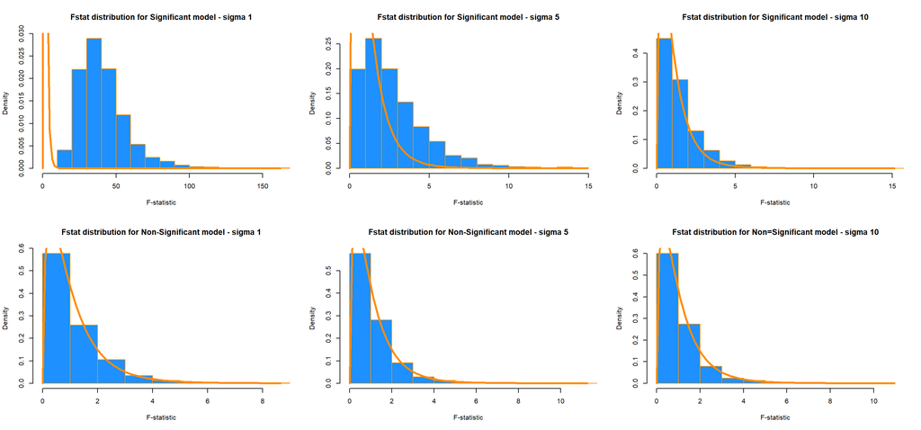

Figure 1.1: Figure 1.1 - Comparison of F-Statistic across Significant and Non-Significant model with Sigma in (1,5,10)

```r
par(mfrow = c(2,3))

hist(Significant_sigma_1_df$f_stat, main = "Fstat distribution for Significant model - sigma 1", prob = TRUE, col = "dodgerblue", border = "darkorange", xlab = "F-statistic", xlim = c(0,max(Significant_sigma_1_df$f_stat)))
x <- Significant_sigma_1_df$f_stat
curve( df(x, df1 = 4 - 1, df2 = 25 -4), col = "darkorange", add = TRUE, lwd = 3)

hist(Significant_sigma_5_df$f_stat, main = "Fstat distribution for Significant model - sigma 5", prob = TRUE, col = "dodgerblue", border = "darkorange", xlab = "F-statistic", xlim = c(0,max(Significant_sigma_5_df$f_stat)))
x <- Significant_sigma_5_df$f_stat
curve( df(x, df1 = 4 - 1, df2 = 25 -4), col = "darkorange", add = TRUE, lwd = 3)

hist(Significant_sigma_10_df$f_stat, main = "Fstat distribution for Significant model - sigma 10", prob = TRUE, col = "dodgerblue", border = "darkorange", xlab = "F-statistic", xlim = c(0,max(Significant_sigma_10_df$f_stat)))
x <- Significant_sigma_10_df$f_stat
curve( df(x, df1 = 4 - 1, df2 = 25 -4), col = "darkorange", add = TRUE, lwd = 3)

# Non Significant Model curves

hist(Nonsignificant_sigma_1_df$f_stat, main = "Fstat distribution for Non-Significant model - sigma 1", prob = TRUE, col = "dodgerblue", border = "darkorange", xlab = "F-statistic", xlim = c(0,max(Nonsignificant_sigma_1_df$f_stat)))
x <- Nonsignificant_sigma_1_df$f_stat
curve( df(x, df1 = 4 - 1, df2 = 25 -4), col = "darkorange", add = TRUE, lwd = 3)

hist(Nonsignificant_sigma_5_df$f_stat, main = "Fstat distribution for Non-Significant model - sigma 5", prob = TRUE, col = "dodgerblue", border = "darkorange", xlab = "F-statistic", xlim = c(0,max(Nonsignificant_sigma_5_df$f_stat)))
x <- Nonsignificant_sigma_5_df$f_stat
curve( df(x, df1 = 4 - 1, df2 = 25 -4), col = "darkorange", add = TRUE, lwd = 3)

hist(Nonsignificant_sigma_10_df$f_stat, main = "Fstat distribution for Non=Significant model - sigma 10", prob = TRUE, col = "dodgerblue", border = "darkorange", xlab = "F-statistic", xlim = c(0,max(Nonsignificant_sigma_10_df$f_stat)))
x <- Nonsignificant_sigma_10_df$f_stat
curve( df(x, df1 = 4 - 1, df2 = 25 -4), col = "darkorange", add = TRUE, lwd = 3)
```

We will discuss the findings from the above graphs in the discussion section below. One quick note here: the reason the top left graph (Significant model, $\sigma=1$) shows the curve squished and before the histogram is that the distribution will fall under the curve when Null hypothesis is true. When Null hypothesis is rejected, with a large F-statistic, the histogram distribution will fall on the tail of the F-curve, as it is seen here. This is discussed in the Discussion section.

Now we plot the distributions of the p-value returned from our 6 different simulations. The label for each graph talks about what the graph represents

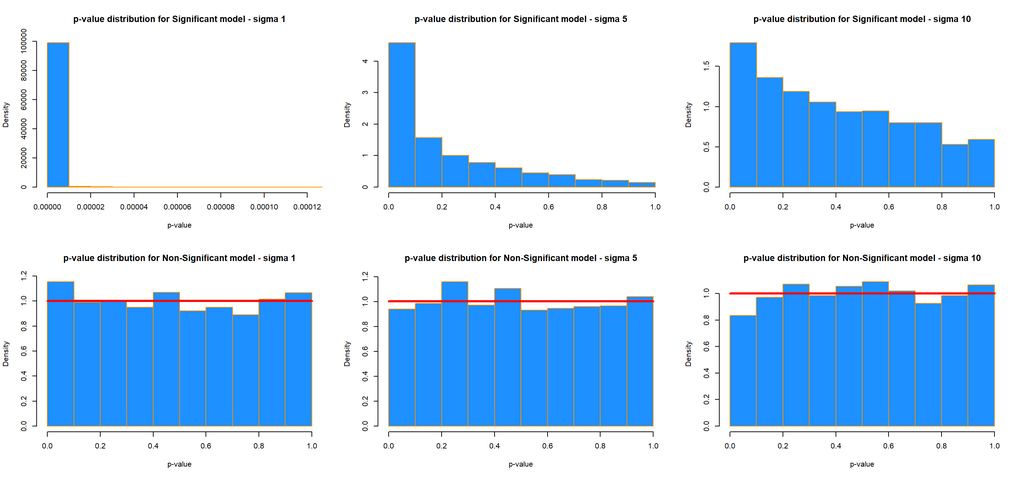

Figure 1.2: Figure 1.2 - Comparison of p-value across Significant and Non-Significant model with Sigma in (1,5,10)

```r
par(mfrow = c(2,3))

hist(Significant_sigma_1_df$pval, main = "p-value distribution for Significant model - sigma 1", prob = TRUE, col = "dodgerblue", border = "darkorange", xlab = "p-value", xlim = c(0,max(Significant_sigma_1_df$pval)))
x <- Significant_sigma_1_df$pval

hist(Significant_sigma_5_df$pval, main = "p-value distribution for Significant model - sigma 5", prob = TRUE, col = "dodgerblue", border = "darkorange", xlab = "p-value", xlim = c(0,max(Significant_sigma_5_df$pval)))
x <- Significant_sigma_5_df$pval

hist(Significant_sigma_10_df$pval, main = "p-value distribution for Significant model - sigma 10", prob = TRUE, col = "dodgerblue", border = "darkorange", xlab = "p-value", xlim = c(0,max(Significant_sigma_10_df$pval)))
x <- Significant_sigma_10_df$pval

# Non Significant Model curves

hist(Nonsignificant_sigma_1_df$pval, main = "p-value distribution for Non-Significant model - sigma 1", prob = TRUE, col = "dodgerblue", border = "darkorange", xlab = "p-value", xlim = c(0,max(Nonsignificant_sigma_1_df$pval)))
x <- Nonsignificant_sigma_1_df$pval
curve( dunif(x, min = min(x), max=max(x)), col = "red", add = TRUE, lwd = 3)

hist(Nonsignificant_sigma_5_df$pval, main = "p-value distribution for Non-Significant model - sigma 5", prob = TRUE, col = "dodgerblue", border = "darkorange", xlab = "p-value", xlim = c(0,max(Nonsignificant_sigma_5_df$pval)))
x <- Nonsignificant_sigma_5_df$pval
curve( dunif(x, min = min(x), max=max(x)), col = "red", add = TRUE, lwd = 3)

hist(Nonsignificant_sigma_10_df$pval, main = "p-value distribution for Non-Significant model - sigma 10", prob = TRUE, col = "dodgerblue", border = "darkorange", xlab = "p-value", xlim = c(0,max(Nonsignificant_sigma_10_df$pval)))
x <- Nonsignificant_sigma_10_df$pval
curve( dunif(x, min = min(x), max=max(x)), col = "red", add = TRUE, lwd = 3)
```

Please see the Discussion section below for analysis of the above graphs

As a final step in our Methods section, we plot the distribution of $R^2$ for the 6 models that we have simulated above.

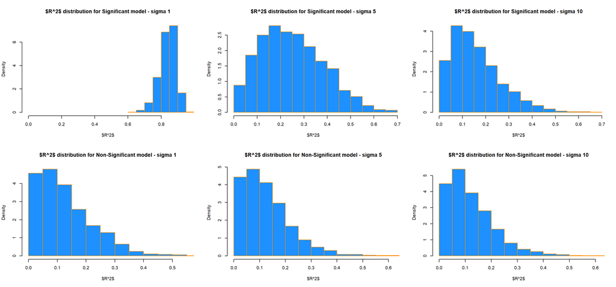

Figure 1.3: Figure 1.3 - Comparison of $R^2$ across Significant and Non-Significant model with Sigma in (1,5,10)

```r
par(mfrow = c(2,3))

hist(Significant_sigma_1_df$r2, main = "$R^2$ distribution for Significant model - sigma 1", prob = TRUE, col = "dodgerblue", border = "darkorange", xlab = "$R^2$", xlim = c(0,max(Significant_sigma_1_df$r2)))

hist(Significant_sigma_5_df$r2, main = "$R^2$ distribution for Significant model - sigma 5", prob = TRUE, col = "dodgerblue", border = "darkorange", xlab = "$R^2$", xlim = c(0,max(Significant_sigma_5_df$r2)))

hist(Significant_sigma_10_df$r2, main = "$R^2$ distribution for Significant model - sigma 10", prob = TRUE, col = "dodgerblue", border = "darkorange", xlab = "$R^2$", xlim = c(0,max(Significant_sigma_10_df$r2)))

# Non Significant Model curves

hist(Nonsignificant_sigma_1_df$r2, main = "$R^2$ distribution for Non-Significant model - sigma 1", prob = TRUE, col = "dodgerblue", border = "darkorange", xlab = "$R^2$", xlim = c(0,max(Nonsignificant_sigma_1_df$r2)))


hist(Nonsignificant_sigma_5_df$r2, main = "$R^2$ distribution for Non-Significant model - sigma 5", prob = TRUE, col = "dodgerblue", border = "darkorange", xlab = "$R^2$", xlim = c(0,max(Nonsignificant_sigma_5_df$r2)))

hist(Nonsignificant_sigma_10_df$r2, main = "$R^2$ distribution for Non-Significant model - sigma 10", prob = TRUE, col = "dodgerblue", border = "darkorange", xlab = "$R^2$", xlim = c(0,max(Nonsignificant_sigma_10_df$r2)))
```

## 1.4 Discussion

The above simulations and the charts are telling on what impact the noise (sigma) and signal (significant parameters) have on our ability to predict.

At the high level, it is clear that as the sigma increases, noise (epsilon) increases. The more the noise, the lesser impact the signal has on our ability to predict.

### 1.4.1 Impact of signal changing with $\sigma = 1$

Let us first examine the impact of signal on our ability to predict.

We will assume that sigma or noise is constant in this discussion so that we can clearly see the impact of the beta parameters in the significant model compared to the Non-significant model

In all the three figures, Figure 1.1, Figure 1.2 and Figure 1.3, we will compare the top and bottom charts for this discussion, since the difference between the top and bottom charts is that the top charts, all the beta parameters are in play and in the bottom charts, only the intercept beta is in play.

It is easiest to compare the charts of sigma = 1 for this discussion, so that noise($\sigma$) does not clutter our findings. Hence we look at them first

When we compare the significant (top) and Non-significant (bottom) chart for sigma =1, in Figure 1.1, we make the below observations

- F-statistic is higher for the significant model. Now F-statistic can be thought of as $F=$ $\text{Mean Square Explained} \over \text{Mean Square Unexplained}$ $=$ $\text{Mean Square Regression} \over \text{Mean Square Error}$ $=$ ${\sum_{i=1}^{𝑛} (\hat{y}_{1i} - \bar{y})^2/p-1 \over \sum_{i=1}^{𝑛} (y_i - \hat{y}_{1i})^2/n-p}$. Hence F-statistic will be high if either the predictors are able to explain the regression OR if the error is high. Since we have fixed $\sigma=1$, we know error or variance is not high. Hence the only explanation for the F-statistic being high in the Significant model is that the model is able to explain the regression. Said differently we can say that for $\sigma=1$ we see that atleast one of the predictors has a significant relationship with the response variable.We will discuss the comparison for other sigmas in section 1.4.2
- If we look at Table 1.1 we see that for the Significant model, for sigma 1, the Null Hypothesis was rejected 100% of times. This conclusion is the same that we have drawn after looking at the F-statistic chart above
- Let us now see if the p-value chart in Figure 1.2 corroborates the above finding. Looking at the top left chart, we see that p-value is 0 for all our simulation runs (significant model, sigma=1). This implies that the Null Hypothesis should be rejected. This implies that we accept the alternate Hypothesis that there is a significant linear relationship between atleast one of the predictors and the response variable
- If the above three theories are correct then our chart for $R^2$ should show $R^2$ value to be very high as most of the variability in the Significant model should be explained by our model when sigma=1. When looking at Figure 1.3 we find that to be the case in the top left chart where sigma=1 for the Significant model.

### 1.4.2 Impact of noise changing ($\sigma$ change impact)

Now we will focus on the change we see when we move from left to right in the charts in our three figures, Figure 1.1, Figure 1.2 and Figure 1.3. As we move from left to right the noise increases and the impact of signal decreases. This implies that our ability to reject the Null Hypothesis, even if it not true, decreases. To summarize, noise (high $\sigma$) is bad for our ability to predict :)

Let us see if the charts and tables support the above statement.

- If we look at Table 1.1 we see that as the sigma increases for the significant model, the Power or the %age of times we reject the Null Hypothesis decreases. Implying if we knew that the Significant model was true, and we simulated the data, our ability to reject the Null hypothesis for the significant model would reduce as sigma increased. Hence for higher levels of sigma, we would make more Type II errors by not rejecting the Null Hypothesis even though the Alternate Hypothesis is true.

For the Non significant model, if we assume the Model to be true, then it does not change the Power by much since we are starting off by saying that there is no relationship between the predictors and response variables.

- The above theory seems to hold ground when we look at sigma changing from left to right in Figure 1.1. $F=$ $\text{Mean Square Explained} \over \text{Mean Square Unexplained}$ $=$ $\text{Mean Square Regression} \over \text{Mean Square Error}$ $=$ ${\sum_{i=1}^{𝑛} (\hat{y}_{1i} - \bar{y})^2/p-1 \over \sum_{i=1}^{𝑛} (y_i - \hat{y}_{1i})^2/n-p}$. Now as sigma increases, the denominator increases and the hence the F-statistic becomes smaller. This is seen in the graph. Hence even if the Significant model was true, we would fail to detect it from the F-statistic for higher values of Sigma. We can see that the F-statistic graph for the significant model with sigma = 10 looks almost the same as the Non Significant model F-statistic for sigma = 1. For the Non-significant models we see that F-statistic doesnt change by much since the non-significant model is stating the the Unexplained is high, hence the denominator in the equation above is high, hence F-statistic is low and similar irrespective of sigma.
- Now we analyze the impact of sigma on the p-value by looking at the graphs in Figure 1.2. For the Significant model, we assume that we know that the model is true, and in our Hypothesis test we should reject the Null Hypothesis. But we see that as the noise increases our ability to reject the Null Hypothesis decreases and the p-value graph starts to tend towards the non-significant model graph and our Type II errors increase with noise. For the non-significant models we see that p-value is uniformly distributes as if attributed purely to chance. Hence all the graphs of p-value for Non significant model are similar.
- Based on what we have observed above, it goes to reason that $R^2$ should also decrease with noise since the variability will increase. That is what we see when we look at Figure 1.3. We see that the impact to $R^2$ is pretty severe even by a slight increase in $\sigma$. $R^2 = 1 - {\text{Sum of Squares Error} \over \text{Sum of Squares Total}} = 1 - {\sum{e^2} \over \sum{(y_i - \bar y)^2}}$. Based on the above equation it goes to reason that as the error increases due to sigma, the impact to $R^2$ is square of the error, hence more extreme. This corroborates what we are seeing in the significant model graph as we move from left to right. For the non significant model we see no impact since we are saying that the model does not explain the response hence $R^2$ is low throughout

### 1.4.3 Distributions of the graphs

Now we analyze if the F-statistic, p-value and $R^2$ graphs follow any standard distributions.

## 1.5 Conclusion

We draw the following two conclusions

1. For a model which has a signal that is useful for prediction, where atleast one of the beta parameters has a significant linear relationship, increase in noise level or $\sigma$ decreases our ability to accurately predict. When doing a Hypothesis test, higher sigma also increases the chances of Type II errors since there is a higher probability of us not rejecting the Null Hypothesis even when the alternate Hypothesis is true.
2. For a model that does not have a useful signal to help us predict, increasing the noise makes no difference in the probability of accepting the Null Hypothesis

# 2 Simulation Study 2: Using RMSE for Selection?

## 2.1 Introduction

In this simulation study we will evaluate if RMSE is a good statistic to choose a best model among a set of nested models. We will also evaluate the effect of $\sigma$ on RMSE

We will use the below model as the true model

$Y_i=β_0+β_1x_{i1}+β_2x_{i2}+β_3x_{i3}+β_4x_i4+β_5x_{i5}+β_6x_{i6}+ϵ_i$

where $ϵ_i ∼ N(0,σ^2)$

We will then simulate data 1000 times. For each simulation we will split the sample into two, where the 1st half will be used to train the data and the 2nd half to test the model prediction.

Then for each simulation, for each training data we will fit the below nine models

```
y ~ x1
y ~ x1 + x2
y ~ x1 + x2 + x3
y ~ x1 + x2 + x3 + x4
y ~ x1 + x2 + x3 + x4 + x5
y ~ x1 + x2 + x3 + x4 + x5 + x6 #the correct form of the model as noted above
y ~ x1 + x2 + x3 + x4 + x5 + x6 + x7
y ~ x1 + x2 + x3 + x4 + x5 + x6 + x7 + x8
y ~ x1 + x2 + x3 + x4 + x5 + x6 + x7 + x8 + x9
```

For each model, we will calculate Train and Test RMSE.

$$\text{RMSE}(\text{model, data}) = \sqrt{\frac{1}{n} \sum_{i = 1}^{n}(y_i - \hat{y}_i)^2}$$

We will repeat this process with $1000$ simulations for each of the $3$ values of $\sigma$. For each value of $\sigma$, we will create a plot that shows how average Train RMSE and average Test RMSE changes as a function of model size. We will also show the number of times the model of each size was chosen for each value of $\sigma$.

## 2.2 Methods

We set the seed to ensure reproducible results

```r
birthday = 19730321
set.seed(birthday)
```

We initialize the variables

```r
x_predictors_df <- read.csv("study_2.csv")

n <- 500
mu <- 0
num_simul <- 1000

beta_0 <- 0
beta_1 <- 3
beta_2 <- -4
beta_3 <- 1.6
beta_4 <- -1.1
beta_5 <- 0.7
beta_6 <- 0.5
```

We define a function that simulates the data, calculates the RMSE for training and testing datasets and return the RMSE

```r
sim_data_calc_RMSE <- function(sample_size, mu, sig, num_simul, x_predictors_df, num_parameters){


  sim_train_RMSE <- rep(0,num_simul)
  sim_test_RMSE <- rep(0,num_simul)

  for (i in 1:num_simul){
    #randomly generate error based on normal distribution
    epsilon <- rnorm(sample_size, mean=mu, sd=sig)
    # Calculate y
    x_predictors_df$y <- beta_0 + x_predictors_df$x1*beta_1 + x_predictors_df$x2*beta_2 + x_predictors_df$x3*beta_3 +
                          x_predictors_df$x4*beta_4 + x_predictors_df$x5*beta_5 + x_predictors_df$x6*beta_6 + epsilon

    # Split data into train and test data - 250 samples each
    trn_idx = sample(1:nrow(x_predictors_df), 250)
    trn <- slice(x_predictors_df, trn_idx)
    tst <- slice(x_predictors_df, -1*trn_idx)

    # Fit training data to model based on number of parameters
    if(num_parameters==2){
      m <- lm(y ~ x1, data = trn)
    } else if(num_parameters==3){
      m <- lm(y ~ x1+x2, data = trn)
    } else if(num_parameters==4){
      m <- lm(y ~ x1+x2+x3, data = trn)
    } else if(num_parameters==5){
      m <- lm(y ~ x1+x2+x3+x4, data = trn)
    } else if(num_parameters==6){
      m <- lm(y ~ x1+x2+x3+x4+x5, data = trn)
    } else if(num_parameters==7){
      m <- lm(y ~ x1+x2+x3+x4+x5+x6, data = trn)
    } else if(num_parameters==8){
      m <- lm(y ~ x1+x2+x3+x4+x5+x6+x7, data = trn)
    } else if(num_parameters==9){
      m <- lm(y ~ x1+x2+x3+x4+x5+x6+x7+x8, data = trn)
    } else{
      m <- lm(y ~ x1+x2+x3+x4+x5+x6+x7+x8+x9, data = trn)
    }
    # calculate RMSE
    sim_train_RMSE[i] <- sqrt(sum((trn["y"]-predict(m))^2)/nrow(trn))
    # Predict y based on testing data and then calculate RMSE
    sim_test_RMSE[i] <- sqrt(sum((tst["y"]-predict(m, newdata = tst))^2)/nrow(tst))
  }
  # return training and testing RMSE for each simulation
  return(data.frame("train_RMSE"=sim_train_RMSE, "test_RMSE"=sim_test_RMSE))
}
```

For sigma 1, we calculate the training and testing RMSE for each model and store it in a separate dataframe for each model

```r
sig <- 1

m1_sig1_df <- sim_data_calc_RMSE(sample_size = n, mu = mu, sig = sig, num_simul = num_simul, x_predictors_df = x_predictors_df, num_parameters = 2)
m2_sig1_df <- sim_data_calc_RMSE(sample_size = n, mu = mu, sig = sig, num_simul = num_simul, x_predictors_df = x_predictors_df, num_parameters = 3)
m3_sig1_df <- sim_data_calc_RMSE(sample_size = n, mu = mu, sig = sig, num_simul = num_simul, x_predictors_df = x_predictors_df, num_parameters = 4)
m4_sig1_df <- sim_data_calc_RMSE(sample_size = n, mu = mu, sig = sig, num_simul = num_simul, x_predictors_df = x_predictors_df, num_parameters = 5)
m5_sig1_df <- sim_data_calc_RMSE(sample_size = n, mu = mu, sig = sig, num_simul = num_simul, x_predictors_df = x_predictors_df, num_parameters = 6)
m6_sig1_df <- sim_data_calc_RMSE(sample_size = n, mu = mu, sig = sig, num_simul = num_simul, x_predictors_df = x_predictors_df, num_parameters = 7)
m7_sig1_df <- sim_data_calc_RMSE(sample_size = n, mu = mu, sig = sig, num_simul = num_simul, x_predictors_df = x_predictors_df, num_parameters = 8)
m8_sig1_df <- sim_data_calc_RMSE(sample_size = n, mu = mu, sig = sig, num_simul = num_simul, x_predictors_df = x_predictors_df, num_parameters = 9)
m9_sig1_df <- sim_data_calc_RMSE(sample_size = n, mu = mu, sig = sig, num_simul = num_simul, x_predictors_df = x_predictors_df, num_parameters = 10)
```

For sigma 2, we calculate the training and testing RMSE for each model and store it in a separate dataframe for each model

```r
sig <- 2

m1_sig2_df <- sim_data_calc_RMSE(sample_size = n, mu = mu, sig = sig, num_simul = num_simul, x_predictors_df = x_predictors_df, num_parameters = 2)
m2_sig2_df <- sim_data_calc_RMSE(sample_size = n, mu = mu, sig = sig, num_simul = num_simul, x_predictors_df = x_predictors_df, num_parameters = 3)
m3_sig2_df <- sim_data_calc_RMSE(sample_size = n, mu = mu, sig = sig, num_simul = num_simul, x_predictors_df = x_predictors_df, num_parameters = 4)
m4_sig2_df <- sim_data_calc_RMSE(sample_size = n, mu = mu, sig = sig, num_simul = num_simul, x_predictors_df = x_predictors_df, num_parameters = 5)
m5_sig2_df <- sim_data_calc_RMSE(sample_size = n, mu = mu, sig = sig, num_simul = num_simul, x_predictors_df = x_predictors_df, num_parameters = 6)
m6_sig2_df <- sim_data_calc_RMSE(sample_size = n, mu = mu, sig = sig, num_simul = num_simul, x_predictors_df = x_predictors_df, num_parameters = 7)
m7_sig2_df <- sim_data_calc_RMSE(sample_size = n, mu = mu, sig = sig, num_simul = num_simul, x_predictors_df = x_predictors_df, num_parameters = 8)
m8_sig2_df <- sim_data_calc_RMSE(sample_size = n, mu = mu, sig = sig, num_simul = num_simul, x_predictors_df = x_predictors_df, num_parameters = 9)
m9_sig2_df <- sim_data_calc_RMSE(sample_size = n, mu = mu, sig = sig, num_simul = num_simul, x_predictors_df = x_predictors_df, num_parameters = 10)
```

For sigma 4, we calculate the training and testing RMSE for each model and store it in a separate dataframe for each model

```r
sig <- 4

m1_sig4_df <- sim_data_calc_RMSE(sample_size = n, mu = mu, sig = sig, num_simul = num_simul, x_predictors_df = x_predictors_df, num_parameters = 2)
m2_sig4_df <- sim_data_calc_RMSE(sample_size = n, mu = mu, sig = sig, num_simul = num_simul, x_predictors_df = x_predictors_df, num_parameters = 3)
m3_sig4_df <- sim_data_calc_RMSE(sample_size = n, mu = mu, sig = sig, num_simul = num_simul, x_predictors_df = x_predictors_df, num_parameters = 4)
m4_sig4_df <- sim_data_calc_RMSE(sample_size = n, mu = mu, sig = sig, num_simul = num_simul, x_predictors_df = x_predictors_df, num_parameters = 5)
m5_sig4_df <- sim_data_calc_RMSE(sample_size = n, mu = mu, sig = sig, num_simul = num_simul, x_predictors_df = x_predictors_df, num_parameters = 6)
m6_sig4_df <- sim_data_calc_RMSE(sample_size = n, mu = mu, sig = sig, num_simul = num_simul, x_predictors_df = x_predictors_df, num_parameters = 7)
m7_sig4_df <- sim_data_calc_RMSE(sample_size = n, mu = mu, sig = sig, num_simul = num_simul, x_predictors_df = x_predictors_df, num_parameters = 8)
m8_sig4_df <- sim_data_calc_RMSE(sample_size = n, mu = mu, sig = sig, num_simul = num_simul, x_predictors_df = x_predictors_df, num_parameters = 9)
m9_sig4_df <- sim_data_calc_RMSE(sample_size = n, mu = mu, sig = sig, num_simul = num_simul, x_predictors_df = x_predictors_df, num_parameters = 10)
```

Now we calculate how many times a model was selected in the simulations for each sigma

```r
sig1_test_RMSE <- cbind("m1"=m1_sig1_df[,2], "m2"=m2_sig1_df[,2], "m3"=m3_sig1_df[,2], "m4"=m4_sig1_df[,2], "m5"=m5_sig1_df[,2], "m6"=m6_sig1_df[,2], "m7"=m7_sig1_df[,2], "m8"=m8_sig1_df[,2], "m9"=m9_sig1_df[,2])

sig1_selected <- colnames(sig1_test_RMSE)[apply(sig1_test_RMSE,1,which.min)]

sig2_test_RMSE <- cbind("m1"=m1_sig2_df[,2], "m2"=m2_sig2_df[,2], "m3"=m3_sig2_df[,2], "m4"=m4_sig2_df[,2], "m5"=m5_sig2_df[,2], "m6"=m6_sig2_df[,2], "m7"=m7_sig2_df[,2], "m8"=m8_sig2_df[,2], "m9"=m9_sig2_df[,2])

sig2_selected <- colnames(sig2_test_RMSE)[apply(sig2_test_RMSE,1,which.min)]

sig4_test_RMSE <- cbind("m1"=m1_sig4_df[,2], "m2"=m2_sig4_df[,2], "m3"=m3_sig4_df[,2], "m4"=m4_sig4_df[,2], "m5"=m5_sig4_df[,2], "m6"=m6_sig4_df[,2], "m7"=m7_sig4_df[,2], "m8"=m8_sig4_df[,2], "m9"=m9_sig4_df[,2])

sig4_selected <- colnames(sig4_test_RMSE)[apply(sig4_test_RMSE,1,which.min)]

sel_df <- data.frame(cbind(sig1_selected, sig2_selected, sig4_selected))

s1 <- table(sel_df$sig1_selected)
s2 <- table(sel_df$sig2_selected)
s4 <- table(sel_df$sig4_selected)

sigma_model_count <- data.frame(cbind("models"=c("m1", "m2", "m3", "m4", "m5", "m6", "m7", "m8", "m9"), "sigma1"=rep(0,9), "sigma2"=rep(0,9), "sigma3"=rep(0,9)))

for(i in 1:9){
 a <- sprintf("m%d",i)
 sigma_model_count[sigma_model_count$models== a,][1,2]=s1[a]
 sigma_model_count[sigma_model_count$models== a,][1,3]=s2[a]
 sigma_model_count[sigma_model_count$models== a,][1,4]=s4[a]
}
sigma_model_count$models <- c("Model 1", "Model 2", "Model 3", "Model 4", "Model 5", "Model 6", "Model 7", "Model 8", "Model 9")
```

We create two dataframes, one for Training RMSE data and one for Testing RMSE data. In each of these dataframes we store the mean RMSE for each model for each Sigma. At the end of this chunk, each of the two dataframes will have 9 rows, one for each model and 3 columns, one for each value of sigma. The data values in this table will be the mean RMSE for those models and sigma.

```r
# create dataframe for Training RMSE
df_train_RMSE <- as.data.frame(rbind(c("Model 1", mean(m1_sig1_df$train_RMSE),mean(m1_sig2_df$train_RMSE), mean(m1_sig4_df$train_RMSE)),
                c("Model 2", mean(m2_sig1_df$train_RMSE),mean(m2_sig2_df$train_RMSE), mean(m2_sig4_df$train_RMSE)),
                c("Model 3", mean(m3_sig1_df$train_RMSE),mean(m3_sig2_df$train_RMSE), mean(m3_sig4_df$train_RMSE)),
                c("Model 4", mean(m4_sig1_df$train_RMSE),mean(m4_sig2_df$train_RMSE), mean(m4_sig4_df$train_RMSE)),
                c("Model 5", mean(m5_sig1_df$train_RMSE),mean(m5_sig2_df$train_RMSE), mean(m5_sig4_df$train_RMSE)),
                c("Model 6", mean(m6_sig1_df$train_RMSE),mean(m6_sig2_df$train_RMSE), mean(m6_sig4_df$train_RMSE)),
                c("Model 7", mean(m7_sig1_df$train_RMSE),mean(m7_sig2_df$train_RMSE), mean(m7_sig4_df$train_RMSE)),
                c("Model 8", mean(m8_sig1_df$train_RMSE),mean(m8_sig2_df$train_RMSE), mean(m8_sig4_df$train_RMSE)),
                c("Model 9", mean(m9_sig1_df$train_RMSE),mean(m9_sig2_df$train_RMSE), mean(m9_sig4_df$train_RMSE))))

colnames(df_train_RMSE) <- c("Model number", "RMSE for Sigma = 1", "RMSE for Sigma = 2", "RMSE for Sigma = 4")
# change RMSE value to numeric
df_train_RMSE$`RMSE for Sigma = 1` <- as.numeric(df_train_RMSE$`RMSE for Sigma = 1`)
df_train_RMSE$`RMSE for Sigma = 2` <- as.numeric(df_train_RMSE$`RMSE for Sigma = 2`)
df_train_RMSE$`RMSE for Sigma = 4` <- as.numeric(df_train_RMSE$`RMSE for Sigma = 4`)


# create dataframe for testing RMSE
df_test_RMSE <- as.data.frame(rbind(c("Model 1", mean(m1_sig1_df$test_RMSE),mean(m1_sig2_df$test_RMSE), mean(m1_sig4_df$test_RMSE)),
                c("Model 2", mean(m2_sig1_df$test_RMSE),mean(m2_sig2_df$test_RMSE), mean(m2_sig4_df$test_RMSE)),
                c("Model 3", mean(m3_sig1_df$test_RMSE),mean(m3_sig2_df$test_RMSE), mean(m3_sig4_df$test_RMSE)),
                c("Model 4", mean(m4_sig1_df$test_RMSE),mean(m4_sig2_df$test_RMSE), mean(m4_sig4_df$test_RMSE)),
                c("Model 5", mean(m5_sig1_df$test_RMSE),mean(m5_sig2_df$test_RMSE), mean(m5_sig4_df$test_RMSE)),
                c("Model 6", mean(m6_sig1_df$test_RMSE),mean(m6_sig2_df$test_RMSE), mean(m6_sig4_df$test_RMSE)),
                c("Model 7", mean(m7_sig1_df$test_RMSE),mean(m7_sig2_df$test_RMSE), mean(m7_sig4_df$test_RMSE)),
                c("Model 8", mean(m8_sig1_df$test_RMSE),mean(m8_sig2_df$test_RMSE), mean(m8_sig4_df$test_RMSE)),
                c("Model 9", mean(m9_sig1_df$test_RMSE),mean(m9_sig2_df$test_RMSE), mean(m9_sig4_df$test_RMSE))))

colnames(df_test_RMSE) <- c("Model number", "RMSE for Sigma = 1", "RMSE for Sigma = 2", "RMSE for Sigma = 4")
# create dataframe for testing RMSE
df_test_RMSE$`RMSE for Sigma = 1` <- as.numeric(df_test_RMSE$`RMSE for Sigma = 1`)
df_test_RMSE$`RMSE for Sigma = 2` <- as.numeric(df_test_RMSE$`RMSE for Sigma = 2`)
df_test_RMSE$`RMSE for Sigma = 4` <- as.numeric(df_test_RMSE$`RMSE for Sigma = 4`)
```

## 2.3 Results

We first show how many times each model was selected for each $\sigma$

```r
knitr::kable(data.frame(sigma_model_count), caption = "Number of times each model was selected based on minimum RMSE in the 1000 simulations for each sigma")
```

Table 2.1: Number of times each model was selected based on minimum RMSE in the 1000 simulations for each sigma

| models | sigma1 | sigma2 | sigma3 |
| --- | --- | --- | --- |
| Model 1 | NA | NA | NA |
| Model 2 | NA | NA | 38 |
| Model 3 | NA | 58 | 126 |
| Model 4 | 1 | 78 | 136 |
| Model 5 | 4 | 83 | 137 |
| Model 6 | 274 | 200 | 162 |
| Model 7 | 260 | 201 | 138 |
| Model 8 | 235 | 206 | 120 |
| Model 9 | 226 | 174 | 143 |

We now create three charts. Each chart visualizes the mean RMSE for each of the 9 models for both the training and testing datasets. This allows us to compare how the RMSE varies across models for training and testing datasets

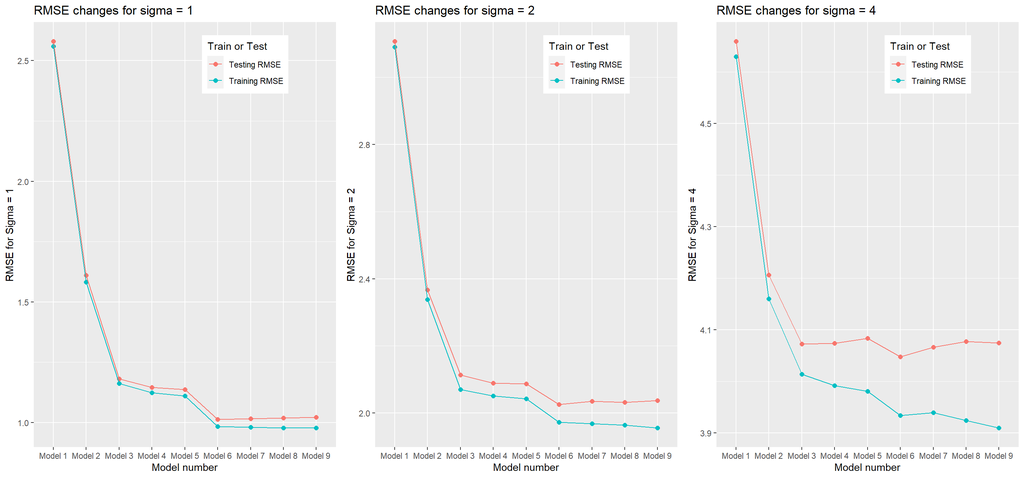

Figure 2.1: Comparison of RMSE change across Test and Train datasets For Sigmas 1, 2 and 4

```r
df_train_RMSE$`Train or Test` <- "Training RMSE"
df_test_RMSE$`Train or Test` <- "Testing RMSE"

combined_df <- rbind(df_train_RMSE, df_test_RMSE)

g1 <- ggplot(data = combined_df, aes(x=`Model number`, y=`RMSE for Sigma = 1`, group = `Train or Test`, color=`Train or Test`)) +
  geom_point(size=2)+
  geom_line() +
  theme(legend.position = c(.7, .9)) +
  ggtitle("RMSE changes for sigma = 1")

g2 <- ggplot(data = combined_df, aes(x=`Model number`, y=`RMSE for Sigma = 2`, group = `Train or Test`, color=`Train or Test`)) +
  geom_point(size=2)+
  geom_line() +
  theme(legend.position = c(.7, .9)) +
  ggtitle("RMSE changes for sigma = 2")

g3 <- ggplot(data = combined_df, aes(x=`Model number`, y=`RMSE for Sigma = 4`, group = `Train or Test`, color=`Train or Test`)) +
  geom_point(size=2)+
  geom_line() +
  theme(legend.position = c(.7, .9)) +
  ggtitle("RMSE changes for sigma = 4")

grid.arrange(g1, g2, g3, ncol=3)
```

Based on the RMSE observed from the testing dataset, we choose model 6 since it has the lowest testing RMSE

We will discuss the above chart in the Discussions section

In order to a visualize this a bit differently, we will create 2 charts, one each for training and testing RMSE, and plot all three sigma values on it

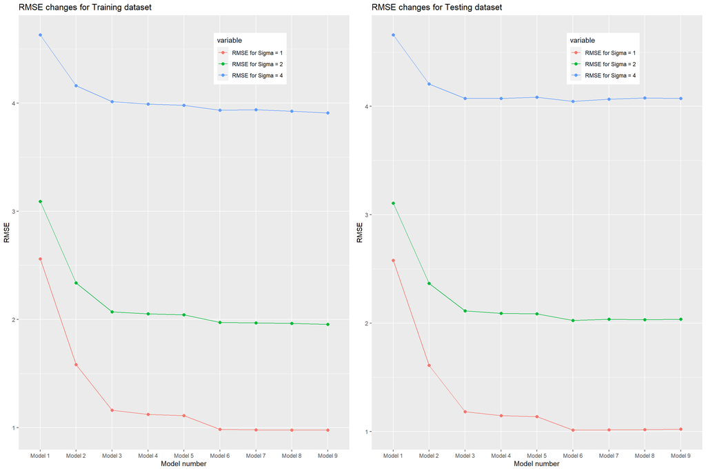

Figure 2.2: Comparison of RMSE change across as sigma changes for Training and Testing datasets

```r
library(reshape2)
melted_df <- melt(combined_df)
colnames(melted_df) <- c(colnames(melted_df)[1:3], "RMSE")

g1 <- ggplot(data = melted_df[melted_df$`Train or Test`=="Training RMSE",], aes(x=`Model number`, y=`RMSE`, group = `variable`, color=`variable`)) +
  geom_point(size=2)+
  geom_line() +
  theme(legend.position = c(.7, .9)) +
  ggtitle("RMSE changes for Training dataset")

g2 <- ggplot(data = melted_df[melted_df$`Train or Test`=="Testing RMSE",], aes(x=`Model number`, y=`RMSE`, group = `variable`, color=`variable`)) +
  geom_point(size=2)+
  geom_line() +
  theme(legend.position = c(.7, .9)) +
  ggtitle("RMSE changes for Testing dataset")

grid.arrange(g1, g2, ncol=2)
```

We will discuss the above chart in the Discussions section

## 2.4 Discussion

In order to understand the study we will look at it from four different aspects

### 2.4.1 Selecting the correct model based on RMSE

Looking at Table 2.1 we see that when sigma is low, due to low noise the impact of signal is clear and model 6 or higher gets selected. It is model 6 or higher, since based on the RMSE formula, there is no penalty for using more parameters.

As the noise increases, we see that some models with less parameters get selected. We can attribute this to chance. The reason we are doing the simulation is to make sure that chance does not effect our model selection.

The correct model doesnt always get selected since RMSE does not punish the model for having more parameters. Hence while picking the model with the least RMSE is important, we should visually examine if there is a model with lesser parameters that has RMSE close to the lowest, even if it is not the lowest, and pick that.

### 2.4.2 Variation betweem Test amd Train RMSE due to number of model parameters

We look at the Figure 2.1. We see that in all three graphs here, as the model parameters increase, the RMSE drops. This trend continues until the number of parameters matches the true model (6), and after that, adding additional parameters doesnt help. In fact, we can see that the additional parameters result in overfitting of the linear model, and hence the testing RMSE slightly worsens on adding additional parameters. We can define RMSE as

$RMSE = {\sum\limits_{i=1}^n(y_i - \hat y) \over \sqrt{n}}$

### 2.4.3 Variation betweem Test amd Train RMSE due to $\sigma$ increasing

As $\sigma$ increases, the noise increases, and hence reduces the impact of signal in the prediction. The end result is that our predictions are less accurate due to more noise. This can be seen in Figure 2.1 as we go from left to right. As the noise is increasing we see the variation between the test and train RMSE increases. This clearly shows that our predictions become less accurate with higher $\sigma$.

This can also be seen mathematically in the equation

$RMSE = {\sum\limits_{i=1}^n(y_i - \hat y) \over \sqrt{n}}$

Implying the closer the predicted value to the actual data, the lesser the RMSE.

Hence as the $\sigma$ increases, the error increases, the predicted value (test data) is further away from the actual value, and RMSE for the same model parameter increases when compared to the training data.

### 2.4.4 Impact to RMSE (either train or test) due to $\sigma$ increasing

We will look at Figure 2.2 to isolate the impact of sigma on the RMSE.

We know that RMSE is defined as

$RMSE = \sqrt{\text {Sum of Squares Error} / n}$

Based on the above equation we see that as the error increases, RMSE increases. This is clearly seen in the plot where we see RMSE for both test and train plots increase significantly as the noise level increases.

This corroborates what we said in the above point, that our ability to predict well reduces with increasing sigma, since the difference between the predicted y and actual y increases.

## 2.5 Conclusion

We draw the following conclusions based on the above observations

- The method of selecting the model that has the least RMSE with the least number of parameters seems like a fair way of selecting a good model. It doesnt always give us the best model as discussed in the Section 2.4.1 above, but on average it does well as a method.
- Adding too many parameters to a model may result in overfitting, hence we should aim to add the least possible parameters that can maintain the RMSE
- As $\sigma$ increases, the error or the noise component increases. This impacts the prediction and hence the RMSE of the test dataset increases, and consequently diverges from the RMSE of the training dataset for the worse

# 3 Simulation Study 3: Power

## 3.1 Introduction

In this simulation study we will investigate the **power** of the significance of regression test for simple linear regression.

$$H_0: \beta_{1} = 0 \ \text{vs} \ H_1: \beta_{1} \neq 0$$

Many things affect the power of a test. In this case, we will investigate these three:

- Sample Size, $n$
- Signal Strength, $\beta_1$
- Noise Level, $\sigma$

To do so we will simulate from the model

$$Y_i = \beta_0 + \beta_1 x_i + \epsilon_i$$

where $\epsilon_i \sim N(0, \sigma^2)$.

For simplicity, we will let $\beta_0 = 0$, thus $\beta_1$ is essentially controlling the amount of “signal.” We will then consider different signals, noises, and sample sizes:

- $\beta_1 \in (-2, -1.9, -1.8, \ldots, -0.1, 0, 0.1, 0.2, 0.3, \ldots 1.9, 2)$
- $\sigma \in (1, 2, 4)$
- $n \in (10, 20, 30)$

We will hold the significance level constant at $\alpha = 0.05$.

## 3.2 Methods

We go about doing the above simulation study using the following method

We set the seed to ensure reproducible results

```r
birthday = 19730321
set.seed(birthday)
```

We initialize the variables

```r
betas <- seq(-2, 2, .1)
sigmas <- c(1,2,4)
ns <- c(10,20,30)
mu <- 0
alpha <- .05
num_simul <- 1000
```

We define a function that simulates data, and then calculates and returns the power

```r
sim_data_calc_Power <- function(sample_size, mu, sig, beta_1, num_simul, x_values, alpha=alpha){

  sim_pval <- rep(0, num_simul)

  for (i in 1:num_simul){
    # generate error based on a random normal distribution
    epsilon <- rnorm(sample_size, mean=mu, sd=sig)

    y <- x_values*beta_1 + epsilon

    m <- lm(y ~ x1, data = data.frame(y, x1=x_values))
    sim_pval[i] <- glance(m)$p.value
  }
  #calculate power
  Power <- mean(sim_pval<alpha)
  return(Power)
}
```

Initialize library so that we can use Cross Join function

```r
library(data.table)
```

```r
Power_df <- CJ(sigmas, ns, betas)

Power_df$Power <- rep(0, nrow(Power_df))
# for each sigma, for each n for each beta, simulate data and calculate Power
for(sigma in sigmas)
{
  for(n in ns)
  {
      x_values = seq(0, 5, length = n)
      for(beta in betas)
      {
        Power_df[Power_df$sigmas==sigma & Power_df$ns==n & Power_df$betas==beta]$Power <-
            sim_data_calc_Power(sample_size=n, mu=mu, sig=sigma, beta_1=beta, num_simul=num_simul, x_values=x_values, alpha=alpha)
    }
  }
}
```

## 3.3 Results

We draw three graphs, one for each $\sigma$. Each graph has a power curve for the three different sample sizes (10,20,30). Here we will show how the Power is effected by the value of $\beta$

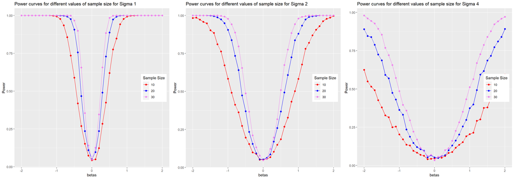

Figure 3.1: Comparison of Power curves for diffrent sample sizes. Sigma increases from left to right

```r
g1 <- ggplot(data = Power_df[Power_df$sigmas==1], aes(x=betas, y=Power, group=as.factor(ns), color=as.factor(ns))) +
  geom_point(size=2) +
  geom_line() +
  theme(legend.position = c(.9, .5)) +
  ggtitle("Power curves for different values of sample size for Sigma 1 ") +
  labs(color = "Sample Size") +
  scale_color_manual(values=c('red','blue','violet'))

g2 <- ggplot(data = Power_df[Power_df$sigmas==2], aes(x=betas, y=Power, group=as.factor(ns), color=as.factor(ns))) +
  geom_point(size=2) +
  geom_line() +
  theme(legend.position = c(.9, .5)) +
  ggtitle("Power curves for different values of sample size for Sigma 2 ") +
  labs(color = "Sample Size") +
  scale_color_manual(values=c('red','blue','violet'))

g3 <- ggplot(data = Power_df[Power_df$sigmas==4], aes(x=betas, y=Power, group=as.factor(ns), color=as.factor(ns))) +
  geom_point(size=2) +
  geom_line() +
  theme(legend.position = c(.9, .5)) +
  ggtitle("Power curves for different values of sample size for Sigma 4 ") +
  labs(color = "Sample Size") +
  scale_color_manual(values=c('red','blue','violet'))

grid.arrange(g1, g2, g3, ncol=3)
```

We will discuss the above plot in the Discussion section

We now see how the power curve is impacted by signal to noise ratio.

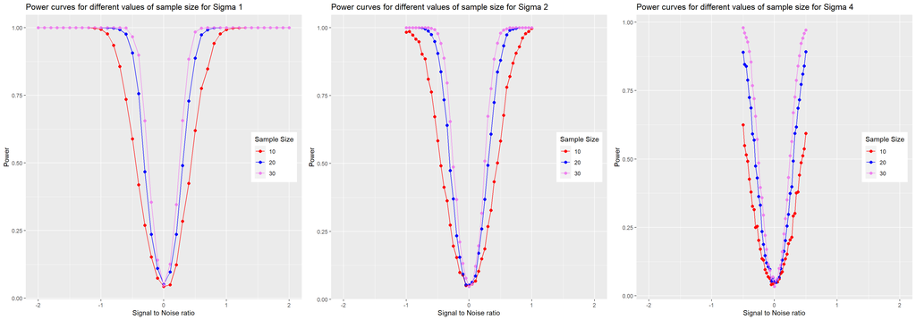

Figure 3.2: Comparison of Power curves vs. Signal to Noise Ratio for diffrent sample sizes. Sigma increases from left to right

```r
g1 <- ggplot(data = Power_df[Power_df$sigmas==1], aes(x=betas/sigmas[1], y=Power, group=as.factor(ns), color=as.factor(ns))) +
  geom_point(size=2) +
  geom_line() +
  theme(legend.position = c(.9, .5)) +
  ggtitle("Power curves for different values of sample size for Sigma 1 ") +
  labs(color = "Sample Size") +
  scale_color_manual(values=c('red','blue','violet')) +
  xlim(-2,2)+
  xlab("Signal to Noise ratio")

g2 <- ggplot(data = Power_df[Power_df$sigmas==2], aes(x=betas/sigmas[2], y=Power, group=as.factor(ns), color=as.factor(ns))) +
  geom_point(size=2) +
  geom_line() +
  theme(legend.position = c(.9, .5)) +
  ggtitle("Power curves for different values of sample size for Sigma 2 ") +
  labs(color = "Sample Size") +
  scale_color_manual(values=c('red','blue','violet')) +
  xlim(-2,2)+
  xlab("Signal to Noise ratio")

g3 <- ggplot(data = Power_df[Power_df$sigmas==4], aes(x=betas/sigmas[3], y=Power, group=as.factor(ns), color=as.factor(ns))) +
  geom_point(size=2) +
  geom_line() +
  theme(legend.position = c(.9, .5)) +
  ggtitle("Power curves for different values of sample size for Sigma 4 ") +
  labs(color = "Sample Size") +
  scale_color_manual(values=c('red','blue','violet')) +
  xlim(-2,2)+
  xlab("Signal to Noise ratio")

grid.arrange(g1, g2, g3, ncol=3)
```

We will discuss the above plot in the discussion section

## 3.4 Discussion

We will look at the above graphs from four different angles

### 3.4.1 Effect of Sample size on Power curve

Looking at Figure 3.1 we see that as the sample size increases, for the same value of $\beta$ and $\sigma$, if amplitude of $\beta$ is less than sigma, we reject more Null Hypothesis given that Alternate Hypothesis is true. Implying we have less Type II errors for higher sample size. This also tells us that the ideal sample size of 30 that we have been told in class has a reason, and with less sample size we will end up with more cases of Type II errors if $\beta$ is less than sigma.

This sample size advantage of 30 diminishes as the amplitude of $\beta$ nears sigma, or becomes greater than sigma.

### 3.4.2 Effect of Sigma on Power curve

Looking at Figure 3.1, when we look from left to right, we see that $\sigma$ is increasing. Here we observe that as the noise increases, given the same beta and sample size, we fail to reject more proportions of Null Hypothesis, and our Type II errors increase.

### 3.4.3 Effect of signal on Power curve

Looking at Figure 3.1, we see that as the amplitude of signal increases, and becomes more than noise, our probability of introducing Type II errors decreases. For lesser values of signal, there are more Type II errors introduced

### 3.4.5 Number of Simulations

We observe that since we did a 1000 simulations, our curves in Figure 3.1 are not smooth. It looks like if we did more simulations the curve would be smooth but 1000 simulations seems to be sufficient

## 3.5 Conclusion

Based on the above, we conclude that

- If amplitude of signal is less than noise, a larger sample size is better. For lesser sample size than 30, we have the probability of more Type II errors when doing Hypothesis testing. Less sample size = More Type II errors
- As $\sigma$ increases, the probability of us introducing more Type II errors increases. More noise = More Type II errors
- As signal becomes less than noise, Type II errors increase
- As the amplitude of signal to noise ratio become 1 or more, the probability of Type II errors becomes 0